# Analysis of FAIMS Pro CV Scans

This document details the analysis of MS data acquired across different CV values using the FAIMS Pro device on the Orbitrap Fusion MS. The sample was a tryptic digest of a HeLa cell lysate that was analyzed in both unlabeled and TMT labeled formats. The runs were all 60-minutes on a 150um ID x 20cm length column packed with 1.9um C18 beads, running at a flow rate of 0.8uL/min.

## Setting up the environment

These are packages you will need for this notebook. For exact versions used, please refer to the session info at the bottom of this notebook.

[output not shown]

Set the base folders where we will do the work.

```r
###########################################################
baseWorkspace = 'C:/Users/chughes/Documents/bccrc/projectsWorkspace/sorensenLab/faimsProTesting'
baseRepository = 'C:/Users/chughes/Documents/bccrc/projectsRepository/sorensenLab/faimsProTesting'
dataRepository = 'D:/msDataTemp/faimsProTesting'
#baseWorkspace = 'C:/Users/chris/OneDrive/Documents/bccrc/projectsWorkspace/sorensenLab/relatedToYbx1'
#baseRepository = 'C:/Users/chris/OneDrive/Documents/bccrc/projectsRepository/sorensenLab/relatedToYbx1'
```

## Data processing - unlabeled samples

The first thing I want to look at is the charge state distribution across the different CV values. I will use the RawTools output files for this and only focus on things that triggered MS2 scans (regardless of whether they generated a peptide hit or not).

Read the files into a list.

```r
###########################################################
cvFiles = list.files(paste(dataRepository, '/singleCvRunsUnlabeled/', sep = ''), pattern = '_Matrix.txt', full.names = TRUE)
cvData = lapply(cvFiles, read_tsv)
names(cvData) = sub('.*400ng_(.*)\\.raw_Matrix\\.txt', '\\1', cvFiles)
```

Process the data for each list entry to get the scan numbers for each charge.

```r
###########################################################
cvCharges = lapply(cvData, function(x) table(x$PrecursorCharge))
names(cvCharges) = names(cvData)
cvChargesDf = as.data.frame(do.call(rbind, cvCharges))
colnames(cvChargesDf) = c('z2','z3','z4')
cvChargesDf$sample = row.names(cvChargesDf)
row.names(cvChargesDf) = NULL
##
cvChargesTib = as_tibble(cvChargesDf) %>%
  filter(!grepl('_', sample)) %>%
  mutate(cv = sub('CV(.*)$', '\\1', sample)) %>%
  pivot_longer(cols = z2:z4, names_to = 'charge', values_to = 'numberOfPrecursors')
cvChargesTib$cv = factor(cvChargesTib$cv, levels = seq(110,10,-5))
```

Make a plot of the non-TMT sample charge distributions per CV.

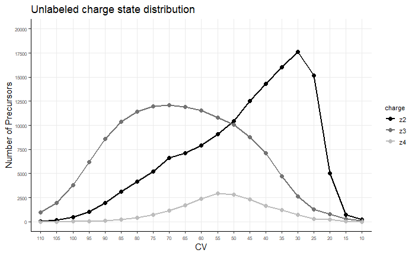

```r
###########################################################
ggplot(cvChargesTib, aes(cv, numberOfPrecursors, group = charge, color = charge)) +
  geom_point(size = 2) +
  geom_line(size = 0.75) +
  labs(x = 'CV', y = 'Number of Precursors', title = 'Unlabeled charge state distribution') +
  scale_color_manual(values = brewer.pal(9,'Greys')[c(9,6,4)]) +
  scale_y_continuous(limits = c(0, 2e4), breaks = seq(0,2e4,2500)) +
  theme_classic() +
  theme(panel.grid.major = element_line(size = 0.25),
        axis.text.x = element_text(size = 6),
        axis.text.y = element_text(size = 6),
        legend.key.size = unit(0.5, 'cm'),
        legend.title = element_text(size = 8),
        legend.text = element_text(size = 8))
ggsave(paste(baseRepository, '/scatter_cvChargeDistributionNonTmt.pdf', sep = ''),
       height = 4, width = 4, useDingbats = FALSE)
```

This looks pretty similar to what has been shown in other papers related to FAIMS Pro by the Coon/Gygi/Olsen labs. This plot actually does a pretty good job of highlighting why a single CV isn’t that useful as you end up filtering a lot of potential peptide ions out.

Plot the MS2 acquisition data.

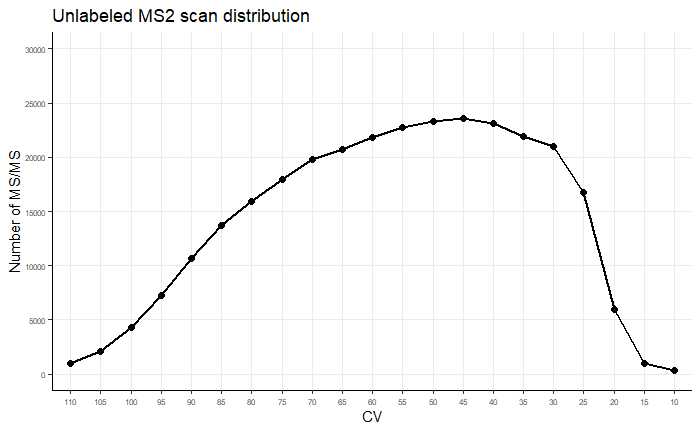

```r
###########################################################
cvMs2Scans = lapply(cvData, function(x) nrow(x))
names(cvMs2Scans) = names(cvData)
cvMs2ScansDf = as.data.frame(do.call(rbind, cvMs2Scans))
colnames(cvMs2ScansDf) = 'ms2Scans'
cvMs2ScansDf$sample = row.names(cvMs2ScansDf)
row.names(cvMs2ScansDf) = NULL

##
cvMs2ScansTib = as_tibble(cvMs2ScansDf) %>%
  mutate(cv = sub('CV(.*)$', '\\1', sample))
cvMs2ScansTib$cv = factor(cvMs2ScansTib$cv, levels = seq(110,10,-5))

##
ggplot(cvMs2ScansTib, aes(cv, ms2Scans, group = 1)) +
  geom_point(size = 2) +
  geom_line(size = 0.75) +
  scale_y_continuous(limits = c(0, 3e4), breaks = seq(0,3e4,5000)) +
  labs(x = 'CV', y = 'Number of MS/MS', title = 'Unlabeled MS2 scan distribution') +
  theme_classic() +
  theme(panel.grid.major = element_line(size = 0.25),
        axis.text.x = element_text(size = 6),
        axis.text.y = element_text(size = 6),
        legend.key.size = unit(0.5, 'cm'),
        legend.title = element_text(size = 8),
        legend.text = element_text(size = 8))
ggsave(paste(baseRepository, '/scatter_cvMs2DistributionNonTmt.pdf', sep = ''),
       height = 4, width = 4, useDingbats = FALSE)
```

Plot the identification data.

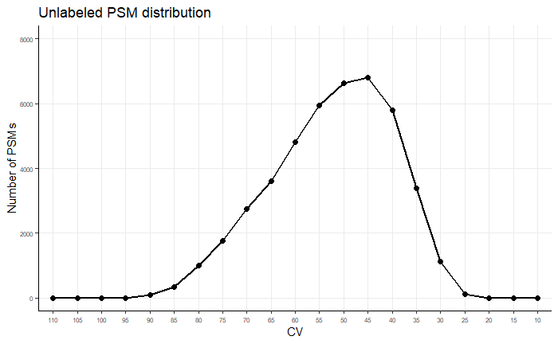

```r
###########################################################
ids = read_csv(paste(dataRepository,'/singleCvRunsUnlabeled/rawtoolsQc/QcDataTable.csv',sep='')) %>%
  dplyr::mutate(cv = factor(sub('.*400ng_CV(.*)\\.raw','\\1',RawFile), levels = seq(110,10,-5))) %>%
  dplyr::select(cv, NumberOfPSMs) %>%
  dplyr::rename('psms' = NumberOfPSMs)
##
ggplot(ids, aes(cv, psms, group = 1)) +
  geom_point(size = 2) +
  geom_line(size = 0.75) +
  scale_y_continuous(limits = c(0, 8e3), breaks = seq(0,8e3,2000)) +
  labs(x = 'CV', y = 'Number of PSMs', title = 'Unlabeled PSM distribution') +
  theme_classic() +
  theme(panel.grid.major = element_line(size = 0.25),
        axis.text.x = element_text(size = 6),
        axis.text.y = element_text(size = 6),
        legend.key.size = unit(0.5, 'cm'),
        legend.title = element_text(size = 8),
        legend.text = element_text(size = 8))
ggsave(paste(baseRepository, '/scatter_cvPsmDistributionNonTmt.pdf', sep = ''),
       height = 4, width = 4, useDingbats = FALSE)
```

## Data processing - labeled samples

Same processing as above, but for TMT labeled samples.

```r
###########################################################
cvFiles = list.files(paste(dataRepository, '/singleCvRunsLabeled/', sep = ''), pattern = '_Matrix.txt', full.names = TRUE)
cvData = lapply(cvFiles, read_tsv)
names(cvData) = sub('.*400ng_(.*)\\.raw_Matrix\\.txt', '\\1', cvFiles)
```

Process the data for each list entry to get the scan numbers for each charge.

```r
###########################################################
cvCharges = lapply(cvData, function(x) table(x$PrecursorCharge))
names(cvCharges) = names(cvData)
cvChargesDf = as.data.frame(do.call(rbind, cvCharges))
colnames(cvChargesDf) = c('z2','z3','z4')
cvChargesDf$sample = row.names(cvChargesDf)
row.names(cvChargesDf) = NULL
##
cvChargesTib = as_tibble(cvChargesDf) %>%
  filter(!grepl('_', sample)) %>%
  mutate(cv = sub('CV(.*)$', '\\1', sample)) %>%
  pivot_longer(cols = z2:z4, names_to = 'charge', values_to = 'numberOfPrecursors')
cvChargesTib$cv = factor(cvChargesTib$cv, levels = seq(110,10,-5))
```

Make a plot of the TMT sample charge distributions per CV.

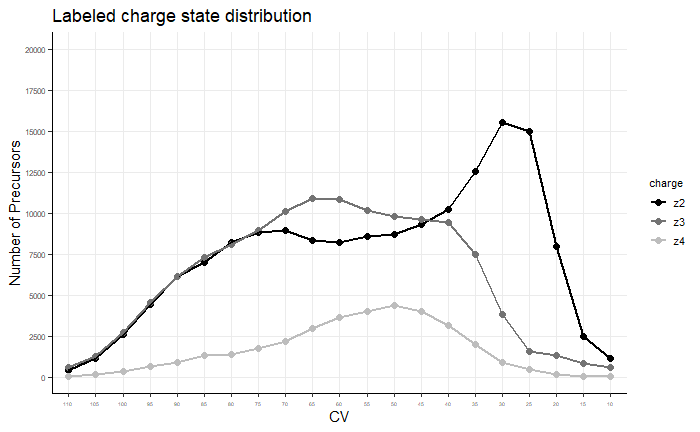

```r
###########################################################
ggplot(cvChargesTib, aes(cv, numberOfPrecursors, group = charge, color = charge)) +
  geom_point(size = 2) +
  geom_line(size = 0.75) +
  labs(x = 'CV', y = 'Number of Precursors', title = 'Labeled charge state distribution') +
  scale_color_manual(values = brewer.pal(9,'Greys')[c(9,6,4)]) +
  scale_y_continuous(limits = c(0, 2e4), breaks = seq(0,2e4,2500)) +
  theme_classic() +
  theme(panel.grid.major = element_line(size = 0.25),
        axis.text.x = element_text(size = 4),
        axis.text.y = element_text(size = 6),
        legend.key.size = unit(0.5, 'cm'),
        legend.title = element_text(size = 8),
        legend.text = element_text(size = 8))
ggsave(paste(baseRepository, '/scatter_cvChargeDistributionTmt.pdf', sep = ''),
       height = 4, width = 4, useDingbats = FALSE)
```

This looks pretty similar to what has been shown in other papers related to FAIMS Pro by the Coon/Gygi/Olsen labs. This plot actually does a pretty good job of highlighting why a single CV isn’t that useful as you end up filtering a lot of potential peptide ions out.

Plot the MS2 acquisition data.

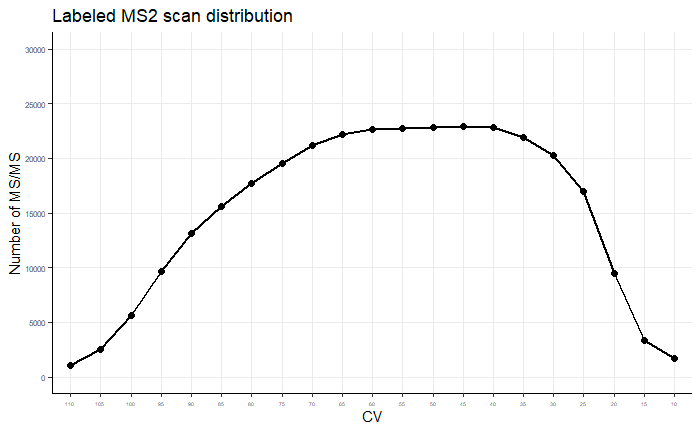

```r
###########################################################
cvMs2Scans = lapply(cvData, function(x) nrow(x))
names(cvMs2Scans) = names(cvData)
cvMs2ScansDf = as.data.frame(do.call(rbind, cvMs2Scans))
colnames(cvMs2ScansDf) = 'ms2Scans'
cvMs2ScansDf$sample = row.names(cvMs2ScansDf)
row.names(cvMs2ScansDf) = NULL

##
cvMs2ScansTib = as_tibble(cvMs2ScansDf) %>%
  mutate(cv = sub('CV(.*)$', '\\1', sample))
cvMs2ScansTib$cv = factor(cvMs2ScansTib$cv, levels = seq(110,10,-5))

##
ggplot(cvMs2ScansTib, aes(cv, ms2Scans, group = 1)) +
  geom_point(size = 2) +
  geom_line(size = 0.75) +
  scale_y_continuous(limits = c(0, 3e4), breaks = seq(0,3e4,5000)) +
  labs(x = 'CV', y = 'Number of MS/MS', title = 'Labeled MS2 scan distribution') +
  theme_classic() +
  theme(panel.grid.major = element_line(size = 0.25),
        axis.text.x = element_text(size = 4),
        axis.text.y = element_text(size = 6),
        legend.key.size = unit(0.5, 'cm'),
        legend.title = element_text(size = 8),
        legend.text = element_text(size = 8))
ggsave(paste(baseRepository, '/scatter_cvMs2DistributionTmt.pdf', sep = ''),
       height = 4, width = 4, useDingbats = FALSE)
```

Plot the identification data.

[figure not shown]

```r
###########################################################
ids = read_csv(paste(dataRepository,'/singleCvRunsLabeled/rawtoolsQc/QcDataTable.csv',sep='')) %>%
  dplyr::mutate(cv = factor(sub('.*400ng_CV(.*)\\.raw','\\1',RawFile), levels = seq(110,10,-5))) %>%
  dplyr::select(cv, NumberOfPSMs) %>%
  dplyr::rename('psms' = NumberOfPSMs)
##
ggplot(ids, aes(cv, psms, group = 1)) +
  geom_point(size = 2) +
  geom_line(size = 0.75) +
  scale_y_continuous(limits = c(0, 8e3), breaks = seq(0,8e3,2000)) +
  labs(x = 'CV', y = 'Number of PSMs', title = 'Unlabeled PSM distribution') +
  theme_classic() +
  theme(panel.grid.major = element_line(size = 0.25),
        axis.text.x = element_text(size = 6),
        axis.text.y = element_text(size = 6),
        legend.key.size = unit(0.5, 'cm'),
        legend.title = element_text(size = 8),
        legend.text = element_text(size = 8))
ggsave(paste(baseRepository, '/scatter_cvPsmDistributionTmt.pdf', sep = ''),
       height = 4, width = 4, useDingbats = FALSE)
```